# Survival Rate Analysis of Titanic

## 1. Analysis of Dataset

- This assignment takes kaggle classic Titanic data set as an example to practice the Python operation of logistic regression. This data is the survival data of Titanic passengers. Titanic, the largest passenger ship at that time, sank in its maiden voyage from Southampton to New York. The Titanic shipwreck is one of the deadliest shipwrecks in peacetime. It is also well known for the movie directed by James Cameron.

```python
import pandas as pd
import numpy as np
titanic = pd.read_csv('titanic.csv')   # Import the dataset and required packages
```

```python
titanic.shape # Show the shape of dataset
```

```
(32, 5)
```

```python
titanic # Show the categories of dataset
```

|  | Class | Sex | Age | Survived | Freq |
| --- | --- | --- | --- | --- | --- |
| 0 | 1st | Male | Child | No | 0 |
| 1 | 2nd | Male | Child | No | 0 |
| 2 | 3rd | Male | Child | No | 35 |
| 3 | Crew | Male | Child | No | 0 |
| 4 | 1st | Female | Child | No | 0 |
| 5 | 2nd | Female | Child | No | 0 |
| 6 | 3rd | Female | Child | No | 17 |
| 7 | Crew | Female | Child | No | 0 |
| 8 | 1st | Male | Adult | No | 118 |
| 9 | 2nd | Male | Adult | No | 154 |
| 10 | 3rd | Male | Adult | No | 387 |
| 11 | Crew | Male | Adult | No | 670 |
| 12 | 1st | Female | Adult | No | 4 |
| 13 | 2nd | Female | Adult | No | 13 |
| 14 | 3rd | Female | Adult | No | 89 |
| 15 | Crew | Female | Adult | No | 3 |
| 16 | 1st | Male | Child | Yes | 5 |
| 17 | 2nd | Male | Child | Yes | 11 |
| 18 | 3rd | Male | Child | Yes | 13 |
| 19 | Crew | Male | Child | Yes | 0 |
| 20 | 1st | Female | Child | Yes | 1 |
| 21 | 2nd | Female | Child | Yes | 13 |
| 22 | 3rd | Female | Child | Yes | 14 |
| 23 | Crew | Female | Child | Yes | 0 |
| 24 | 1st | Male | Adult | Yes | 57 |
| 25 | 2nd | Male | Adult | Yes | 14 |
| 26 | 3rd | Male | Adult | Yes | 75 |
| 27 | Crew | Male | Adult | Yes | 192 |
| 28 | 1st | Female | Adult | Yes | 140 |
| 29 | 2nd | Female | Adult | Yes | 80 |
| 30 | 3rd | Female | Adult | Yes | 76 |
| 31 | Crew | Female | Adult | Yes | 20 |

```python
freq = titanic.Freq.to_numpy()
freq # In order to randomly divide the dataset into training set and test set, we change variable Freq to an array named freq.
```

```
array([  0,   0,  35,   0,   0,   0,  17,   0, 118, 154, 387, 670,   4,
        13,  89,   3,   5,  11,  13,   0,   1,  13,  14,   0,  57,  14,
        75, 192, 140,  80,  76,  20])
```

```python
index = np.repeat(np.arange(32), freq) # Repeat each element in np.arange(32) according to the frequency of freq, then name as index.
index.shape
```

```
(2201,)
```

```python
index[:100] # Show the first 100 values.
```

```
array([2, 2, 2, 2, 2, 2, 2, 2, 2, 2, 2, 2, 2, 2, 2, 2, 2, 2, 2, 2, 2, 2,
       2, 2, 2, 2, 2, 2, 2, 2, 2, 2, 2, 2, 2, 6, 6, 6, 6, 6, 6, 6, 6, 6,
       6, 6, 6, 6, 6, 6, 6, 6, 8, 8, 8, 8, 8, 8, 8, 8, 8, 8, 8, 8, 8, 8,
       8, 8, 8, 8, 8, 8, 8, 8, 8, 8, 8, 8, 8, 8, 8, 8, 8, 8, 8, 8, 8, 8,
       8, 8, 8, 8, 8, 8, 8, 8, 8, 8, 8, 8])
```

```python
titanic = titanic.iloc[index, :]  # Generate the whole samples with variable Freq
titanic = titanic.drop('Freq', axis=1)  # Throw away the Freq variable
titanic.info()  # Now the dataset has 2201 observed data and 4 variables
```

```
<class 'pandas.core.frame.DataFrame'>
Int64Index: 2201 entries, 2 to 31
Data columns (total 4 columns):
 #   Column    Non-Null Count  Dtype
---  ------    --------------  -----
 0   Class     2201 non-null   object
 1   Sex       2201 non-null   object
 2   Age       2201 non-null   object
 3   Survived  2201 non-null   object
dtypes: object(4)
memory usage: 86.0+ KB
```

```python
titanic.describe() # Show the characteristics
```

|  | Class | Sex | Age | Survived |
| --- | --- | --- | --- | --- |
| count | 2201 | 2201 | 2201 | 2201 |
| unique | 4 | 2 | 2 | 2 |
| top | Crew | Male | Adult | No |
| freq | 885 | 1731 | 2092 | 1490 |

- Table shows that 1490 passengers died (Survived = no) while 711 survived. In movie, we know that captain carried out the the priority policy for women and children. So let's see whether it is true?

```python
pd.crosstab(titanic.Sex, titanic.Survived)
```

| Survived Sex | No | Yes |
| --- | --- | --- |
| Female | 126 | 344 |
| Male | 1364 | 367 |

```python
pd.crosstab(titanic.Sex, titanic.Survived, normalize='index') # normalize='index' means normalize over each row.
```

| Survived Sex | No | Yes |
| --- | --- | --- |
| Female | 0.268085 | 0.731915 |
| Male | 0.787984 | 0.212016 |

- It seems that female has 73.19% survival rate while male is just 21.2%. So it is true.

```python
pd.crosstab(titanic.Class, titanic.Survived, normalize='index')
```

| Survived Class | No | Yes |
| --- | --- | --- |
| 1st | 0.375385 | 0.624615 |
| 2nd | 0.585965 | 0.414035 |
| 3rd | 0.747875 | 0.252125 |
| Crew | 0.760452 | 0.239548 |

- There are differences of survival rate between classes.

## 2. Logistic Regression

```python
from sklearn.model_selection import train_test_split
import statsmodels.api as sm
from patsy import dmatrices
```

```python
train, test = train_test_split(titanic, test_size=0.3, stratify=titanic.Survived, random_state=0) # Using stratified sampling to make the result better.
y_train, X_train = dmatrices('Survived~Class+Sex+Age', data=train, return_type='dataframe')  # Change categorical variables to dummy variables
pd.options.display.max_columns = 10
X_train.head()
```

|  | Intercept | Class[T.2nd] | Class[T.3rd] | Class[T.Crew] | Sex[T.Male] | Age[T.Child] |
| --- | --- | --- | --- | --- | --- | --- |
| 11 | 1.0 | 0.0 | 0.0 | 1.0 | 1.0 | 0.0 |
| 27 | 1.0 | 0.0 | 0.0 | 1.0 | 1.0 | 0.0 |
| 22 | 1.0 | 0.0 | 1.0 | 0.0 | 0.0 | 1.0 |
| 11 | 1.0 | 0.0 | 0.0 | 1.0 | 1.0 | 0.0 |
| 27 | 1.0 | 0.0 | 0.0 | 1.0 | 1.0 | 0.0 |

```python
y_train.head()
```

|  | Survived[No] | Survived[Yes] |
| --- | --- | --- |
| 11 | 1.0 | 0.0 |
| 27 | 0.0 | 1.0 |
| 22 | 0.0 | 1.0 |
| 11 | 1.0 | 0.0 |
| 27 | 0.0 | 1.0 |

- Automatically generate dummy variables and drop the redundant variables. But still y_train has one redundant.

```python
y_train= y_train.iloc[:, 1]
y_test, X_test = dmatrices('Survived~Class+Sex+Age', data=test, return_type='dataframe')
y_test= y_test.iloc[:, 1] # The same for test data
```

```python
model = sm.Logit(y_train, X_train)
results = model.fit()
```

```
Optimization terminated successfully.
         Current function value: 0.501935
         Iterations 6
```

```python
results.params # To find the estimated coefficients
```

```
Intercept        2.023452
Class[T.2nd]    -1.045877
Class[T.3rd]    -1.869105
Class[T.Crew]   -0.882650
Sex[T.Male]     -2.355785
Age[T.Child]     1.126943
dtype: float64
```

```python
np.exp(results.params) # To find the OR value(Odds Ratio)
```

```
Intercept        7.564391
Class[T.2nd]     0.351384
Class[T.3rd]     0.154262
Class[T.Crew]    0.413685
Sex[T.Male]      0.094819
Age[T.Child]     3.086208
dtype: float64
```

```python
results.summary()
```

Logit Regression Results

| Dep. Variable: | Survived[Yes] | No. Observations: | 1540 |
| --- | --- | --- | --- |
| Model: | Logit | Df Residuals: | 1534 |
| Method: | MLE | Df Model: | 5 |
| Date: | Fri, 07 May 2021 | Pseudo R-squ.: | 0.2019 |
| Time: | 08:11:22 | Log-Likelihood: | -772.98 |
| converged: | True | LL-Null: | -968.52 |
| Covariance Type: | nonrobust | LLR p-value: | 2.482e-82 |

|  | coef | std err | z | P>\|z\| | [0.025 | 0.975] |
| --- | --- | --- | --- | --- | --- | --- |
| Intercept | 2.0235 | 0.200 | 10.141 | 0.000 | 1.632 | 2.415 |
| Class[T.2nd] | -1.0459 | 0.232 | -4.509 | 0.000 | -1.501 | -0.591 |
| Class[T.3rd] | -1.8691 | 0.206 | -9.059 | 0.000 | -2.273 | -1.465 |
| Class[T.Crew] | -0.8826 | 0.192 | -4.598 | 0.000 | -1.259 | -0.506 |
| Sex[T.Male] | -2.3558 | 0.167 | -14.079 | 0.000 | -2.684 | -2.028 |
| Age[T.Child] | 1.1269 | 0.287 | 3.927 | 0.000 | 0.565 | 1.689 |

## 3.Prediction

```python
table = results.pred_table()
table # Show the confusion matrix
```

```
array([[949.,  94.],
       [252., 245.]])
```

```python
Accuracy = (table[0,0]+table[1,1])/np.sum(table)
Error_rate=1-Accuracy
Sensitivity = table[1,1]/(table[1,0]+table[1,1])
Specification = table[0,0]/(table[0,0]+table[0,1])
print('\033[1;46m Accuracy \033[0m')
print(Accuracy)
print('\033[1;46m Error_rate \033[0m')
print(Error_rate)
print('\033[1;46m Sensitivity \033[0m')
print(Sensitivity)
print('\033[1;46m Specification \033[0m')
print(Specification)
```

```
 Accuracy
0.7753246753246753
 Error_rate
0.2246753246753247
 Sensitivity
0.49295774647887325
 Specification
0.909875359539789
```

```python
prob = results.predict(X_test)
pred = (prob >= 0.5)
table = pd.crosstab(y_test, pred, colnames=['Predicted'])
table  # Use test data to predict
```

| Predicted Survived[Yes] | False | True |
| --- | --- | --- |
| 0.0 | 415 | 32 |
| 1.0 | 110 | 104 |

```python
import matplotlib.pyplot as plt
from sklearn.linear_model import LogisticRegression
from sklearn.metrics import classification_report
from sklearn.metrics import cohen_kappa_score
from sklearn.metrics import plot_roc_curve
```

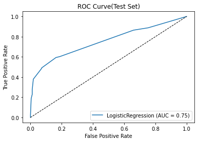

```python
model = LogisticRegression(C=1e10)
model.fit(X_train, y_train)
plot_roc_curve(model, X_test, y_test)
x = np.linspace(0,1,100)
plt.plot(x, x, 'k--', lw=1)
plt.title('ROC Curve(Test Set)')
```

```python
cohen_kappa_score(y_test, pred) # Calculate the Kappa index
```

```
0.4578900555613312
```

## 4.Conclusion

- This analysis mainly explores the relationship between the survival rate of Titanic and various factors (cabin class, age, gender).
- The number of samples is 2201. After the shipwreck, there are 711 survivors. There are four cabin types on the Titanic: first class, second class, third class and crew. The survival rate was 62.46% for first class, 41.4% for second class, 25.21% for third class and 23.95% for crew. It can be seen that the higher the cabin level, the higher the survival rate.
- The survival rate of females was 73.19%, which was much higher than that of males (21.2%). It can be seen that women are more likely to survive than men in this accident, indicating that the principle of "women first" has been carried forward in this accident.
- Regression results showed that the three factors had significant effects on the survival rate.